# Capstone Project - Where do I move?

### Applied Data Science Capstone by IBM/Coursera

- Introduction: Business Problem
- Data
- Methodology
- Analysis
- Results and Discussion
- Conclusion

# Introduction

The main idea behind the proyect is to provide a mean to compare cities based on some specific parameters. Lets say for example that you want to move from one city to the other , and want to live in a neighborhood with some similarities to the one you are currently living. This analisys is based on the assumption that the most important parameters when choosing a neighborhood are schools ,supermarkets, and hospitals as well as the distance to the city center.

```python
import json
#!pip install folium
import folium
import matplotlib.colors as colors
#!pip install geojson
import geojson
#!pip install pandas
import pandas as pd
#!pip install geopy
from geopy import Nominatim
import requests
#!pip install geocoder
import geocoder
import numpy as np
from re import search
import math
import matplotlib.pyplot as plt
import matplotlib.cm as cm
```

### The origin city , in this example , will be Rosario ,Argentina.

```python
mapa = folium.Map(
    location=[-32.9575, -60.639444],
    zoom_start=12,
)
mapa
```

Make this Notebook Trusted to load map: File -> Trust Notebook

[interactive chart not shown]

### This city will be used to train a model to group neighborhoods (clustering) so i can determine wich cluster my current neighborhood is.

### Once this is done , the nex step is to process the data related to the destination city to get the neigbhorhoods most suitable to live in (based on mu current one)

## The destination city will be Cordoba Argentina

```python
mapa1 = folium.Map(
    location=(-31.416667,-64.183333),
    zoom_start=12,
)

mapa1
```

Make this Notebook Trusted to load map: File -> Trust Notebook

[interactive chart not shown]

# Data Used

For this project i used geographical information that i get from goverment datasets.

```python
import json
#!pip install folium
import folium
import matplotlib.colors as colors
#!pip install geojson
import geojson
#!pip install pandas
import pandas as pd
#!pip install geopy
from geopy import Nominatim
import requests
#!pip install geocoder
import geocoder
import numpy as np
from re import search
import math
import matplotlib.pyplot as plt
import matplotlib.cm as cm
```

## The 'barrios_2010_dgeyc.geojson' is a json file where is stored the information related to neigborhoods in the city of Cordoba.

```python
with open('barrios_2010_dgeyc.geojson') as file:
    cba=geojson.load(file)
```

```python
cba['features'][0]
```

```
{"geometry": {"coordinates": [[[[-64.101827, -31.39193], [-64.102482, -31.39127], [-64.103064, -31.390684], [-64.103514, -31.390238], [-64.105036, -31.389944], [-64.105936, -31.389764], [-64.106423, -31.389696], [-64.107119, -31.389719], [-64.107723, -31.389853], [-64.108588, -31.389912], [-64.10893…
```

### As we can see , in the geojson we have the coordinate values to draw each neighborhood , and a propertie call "NOMBRE_BAR" where is stored the neighborhood NAME

## Te 'barrios_json" is a csv with similar iformation but in this case related to the city of Rosario

```python
ros=pd.read_csv('barrios_json.csv')
ros.head()
```

|  | MSLINK | BARRIO | OBSERVACIO | GEOJSON |
| --- | --- | --- | --- | --- |
| 0 | 28 | Victoria Walsh | NaN | { "type": "Feature", "properties": "", "geomet... |
| 1 | 38 | 14 de Octubre | NaN | { "type": "Feature", "properties": "", "geomet... |
| 2 | 50 | Docente "Hermanas Cossettini" | NaN | { "type": "Feature", "properties": "", "geomet... |
| 3 | 22 | Latinoamerica | NaN | { "type": "Feature", "properties": "", "geomet... |
| 4 | 47 | Bella Vista | NaN | { "type": "Feature", "properties": "", "geomet... |

### Here the information about the neighborhood name is in the BARRIO column , and is a GEOJSON column with the coordinates for each one

# Lets plot this information into maps

```python
mapa = folium.Map(
    location=[-32.9575, -60.639444],
    zoom_start=12,
)
for data in ros['GEOJSON']:
    folium.features.GeoJson(data).add_to(mapa)
mapa
```

Make this Notebook Trusted to load map: File -> Trust Notebook

[interactive chart not shown]

```python
m_cba = folium.Map(
    location=(-31.416667,-64.183333),
    zoom_start=12

)
for data in cba['features'] :
    folium.features.GeoJson(data).add_to(m_cba)
m_cba
```

Make this Notebook Trusted to load map: File -> Trust Notebook

[interactive chart not shown]

## Finally i will use Foursquiare API to get the information i need to create the clusters.

## Methodology

As stated in the introduction , the main objective of this analysis is to determine wich neighborhoods of th ecity of Cordoba are similar to the one I currently live To do this , firs i need to group the neighborhoods in Rosario using some clustering algorithm , and once i have the model trained , i will do the same with the neighborhoods in cordoba to get wich are similar to mine. The parameter used will be the precense of schools , hospitals and supermarkets as well as the distance to the ciry center. To get this information first i needede to get an aproximate location of the neighborhood center, since the data dont have it . Once this done , will query information about what i need using foursquiare API looking some distance arround the neighborhood center. Since there is no certanty that i will get the same amount of categories in both cities , i need to group them in bigger ones . For example , the category "Secondary school " and "School" both will be part of the "ESCUELA" (SCHOOL) category. The same with the other ones. Finally i will train Kmeans clustering algorithm with the city of Rosario to then use it to cluster Cordoba.

## Analysis

In the **Data Used** section we get all the geospatial information we need to havee all the neighborhood coordinates for both cities.

First lets define some function to hel us process this data.

```python
#This funcion calculate the aproximate center to a list of 2 dimentional points
def calculateCenter(  points ) :
    longitudes = []
    latitudes = []

    for l in points[0]:
        longitudes.append(l[0])
        latitudes.append(l[1])
    latitudes.sort();
    longitudes.sort();

    lowX = latitudes[-1];
    highX = latitudes[0];
    lowy = longitudes[0];
    highy = longitudes[-1];

    centerX = lowX + ((highX - lowX) / 2);
    centerY = lowy + ((highy - lowy) / 2);

    return(centerX, centerY);
```

```python
#This function recibes a serie with all the geospatial points , and a list with the names of the neighborhoods and calculate the center of each one
def NombreyCoordenadas(serie,nombres):
    centro=[]
    barrio=[]
    result={}
    for i,s in enumerate(serie):
        #print(s)
        j=json.loads(s)
        lista=j['geometry']['coordinates']
        centro.append(calculateCenter(lista))
        barrio.append(nombres[i])
    result['Barrio']=barrio
    result['Coordenadas']=centro

    return(pd.DataFrame(result),centro)
```

```python
#This funcion recibe a lsit of neighborhoods , iths centers  and the center of the city and calculate the distance to the city center. it return a
# dataframe with all this informaiton
def distCentro(barrios,centro,centro_barrio):
    result={}
    distancia=[]
    n=[]
    for i,c in enumerate(centro_barrio.values):
        dist=math.sqrt((centro[0]-c[0])**2+((centro[1]-c[1])**2))
        distancia.append(dist)
        n.append(barrios[i])

    result['Barrio']=n
    result['Distancia']=distancia

    return(pd.DataFrame(result))
```

```python
centro_rosario=[-32.9575, -60.639444]
```

```python
data_ros,centros=NombreyCoordenadas(ros['GEOJSON'],ros['BARRIO'])
```

```python
aux=distCentro(barrios=data_ros['Barrio'],centro=centro_rosario,centro_barrio=data_ros['Coordenadas'])
```

```python
data_ros=data_ros.join(aux.set_index('Barrio'),on='Barrio')
```

```python
m = folium.Map(
    location=centro_rosario,
    zoom_start=10,
)
for data in ros['GEOJSON']:
    folium.features.GeoJson(data).add_to(m)
for c in data_ros.values:

    folium.Marker(c[1],popup=c[0]).add_to(m)
m
```

Make this Notebook Trusted to load map: File -> Trust Notebook

[interactive chart not shown]

### Now that i have all the centers , the next step is to use Foursquare API to get the infomation i need

```python
def searchVenues(queries,nombre,latlong):
    #solo busca si le pasas varias coordenadas
    venues_list=[[(np.nan,np.nan,np.nan,np.nan,np.nan,np.nan,np.nan)]]
    CLIENT_ID = 'WBGNJBOCFXD2VRVRQSNSQIDDE4GA0NBUODKSD5Z0BUL42DJ3' # your Foursquare ID
    CLIENT_SECRET = 'I1XABE44UHI3YU5ZXYOBA40BCLYPOIFCCKRLDJCSAZJJXHLE' # your Foursquare Secret
    ACCESS_TOKEN = 'BL1VQW1S4VKNGWGYDBEDFVAHFPANZI2UNVDAPMENLDQKC2IU'
    VERSION = '20180605' # Foursquare API version
    LIMIT = 100 # A default Foursquare API limit value
    radius=300
    for q in queries:
        print(q)
        for n,ll in zip(nombre,latlong) :
        #    print(n,ll)
            url = 'https://api.foursquare.com/v2/venues/search?client_id={}&client_secret={}&ll={},{}&oauth_token={}&v={}&query={}&radius={}&limit={}'.format(CLIENT_ID,
            CLIENT_SECRET,
            ll[0],
            ll[1],
            ACCESS_TOKEN,
            VERSION,
            q,
            radius,
            LIMIT)
            print(url)
            results = requests.get(url).json()["response"]['venues']
        # return only relevant information for each nearby venue
        #se rompe si viene vacio
            #print(url)
            for v in results:
                    try:
                        venues_list.append([(
                        n,
                        ll[0],
                        ll[1],
                        v['name'],
                        v['location']['lat'],
                        v['location']['lng'],
                        v['categories'][0]['name'])])
                        break
                    except IndexError:
                            venues_list.append([(
                        n,
                        ll[0],
                        ll[1],
                        v['name'],
                        v['location']['lat'],
                        v['location']['lng'],
                        np.nan)])
    nearby_venues = pd.DataFrame([item for venue_list in venues_list for item in venue_list])
    nearby_venues.columns = ['Neighborhood',
                  'Neighborhood Latitude',
                  'Neighborhood Longitude',
                  'Venue',
                  'Venue Latitude',
                  'Venue Longitude',
                  'Venue Category']
    return(nearby_venues)
```

The Code used to lookup information using foursquare was this:

```
        queries=["ESCUELA",'SUPERMERCADO','HOSPITAL']
        venues_found=searchVenues(queries=queries,nombre=data_ros['Barrio'],
                          latlong=data_ros['Coordenadas'],
                          )
        venues_found.to_csv("venues_found.csv")
```

```python
venues_found=pd.read_csv('venues_found.csv')
```

```python
venues_found.dropna(inplace=True)
```

```python
venues_found.reset_index(drop=True,inplace=True)
```

```python
#This funtion doeas the important part of grouping the catecgories

def correctorCategoria(datos):
    #devuelve el df que deberia ser  barrio,lat barrio, long barrio , venue , venue lat , venue long, venue categoria modificado
    df=datos.copy()
    df.reset_index(drop=True)
    #print(df.head())
    #Primero modifico para tener clara la categoria
    es=['School','school','Colleg','colleg']
    sc=['Store','store','marke','Marke','sho','Sho']
    ho=['Hospita','hospita','Medica','medica']
    for i,row in enumerate(df['Venue Category'].values):
        for e in es:
            if bool(search(e,row)):
                #print(i,e,row)
                df.at[i,'Venue Category',]='ESCUELA'
    for i,row in enumerate(df['Venue Category'].values):
        for s in sc:
            #print(row,s)
            if s in row:

                df.at[i,'Venue Category']='SUPERMERCADO'
    for i,row in enumerate(df['Venue Category'].values):
        for h in ho:
                if h in row:
                     df.at[i,'Venue Category']='HOSPITAL'

    for i,row in enumerate(df['Venue Category'].values):
        if bool(not(search('ESCUELA',row))):
            if bool(not(search('HOSPITAL',row))):
                if bool(not(search('SUPERMERCADO',row))):
                        df.drop(i,inplace=True)


    return(df)
```

```python
venues_found.drop(columns=['Unnamed: 0'],inplace=True)
venues_found.reset_index(drop=True,inplace=True)
```

```python
venues_found=correctorCategoria(venues_found)
```

[output not shown]

### Now that i have all the correct categories , its time to start the modeling. First with getting the one hot data

```python
onehot=pd.get_dummies(venues_found,columns=['Venue Category']) # hago onehot
```

```python
data_ros.rename(columns={'Barrio':'Neighborhood'},inplace=True)
data_ros.columns
```

```
Index(['Neighborhood', 'Coordenadas', 'Distancia'], dtype='object')
```

```python
grupped=onehot.groupby('Neighborhood').mean()
grupped.reset_index(inplace=True)
```

```python
grupped.head()
```

|  | Neighborhood | Neighborhood Latitude | Neighborhood Longitude | Venue Latitude | Venue Longitude | Venue Category_ESCUELA | Venue Category_HOSPITAL | Venue Category_SUPERMERCADO |
| --- | --- | --- | --- | --- | --- | --- | --- | --- |
| 0 | 14 de Octubre | -32.996932 | -60.663233 | -33.000656 | -60.655955 | 0.500000 | 0.000000 | 0.500000 |
| 1 | Alberdi | -32.890869 | -60.700978 | -32.882774 | -60.700449 | 0.333333 | 0.333333 | 0.333333 |
| 2 | Alberto Olmedo | -32.937113 | -60.658494 | -32.936458 | -60.661655 | 0.333333 | 0.333333 | 0.333333 |
| 3 | Alvear | -32.984731 | -60.674335 | -32.992312 | -60.674171 | 0.500000 | 0.000000 | 0.500000 |
| 4 | Antártida Argentina | -32.949913 | -60.741915 | -32.942180 | -60.736140 | 1.000000 | 0.000000 | 0.000000 |

### Next I join the grupped data with the distance to the center data

```python
grupped.reset_index(inplace=True,drop=True)
```

```python
#joiin groupped with data_ros to get distance to city center

grupped=grupped.join(data_ros[['Neighborhood','Distancia']].set_index('Neighborhood'),on='Neighborhood')
```

```python
grupped.reset_index(inplace=True,drop=True)
```

```python
grupped.drop(columns=['Venue Latitude','Venue Longitude'],inplace=True)
grupped.head()
```

|  | Neighborhood | Neighborhood Latitude | Neighborhood Longitude | Venue Category_ESCUELA | Venue Category_HOSPITAL | Venue Category_SUPERMERCADO | Distancia |
| --- | --- | --- | --- | --- | --- | --- | --- |
| 0 | 14 de Octubre | -32.996932 | -60.663233 | 0.500000 | 0.000000 | 0.500000 | 0.046052 |
| 1 | Alberdi | -32.890869 | -60.700978 | 0.333333 | 0.333333 | 0.333333 | 0.090698 |
| 2 | Alberto Olmedo | -32.937113 | -60.658494 | 0.333333 | 0.333333 | 0.333333 | 0.027903 |
| 3 | Alvear | -32.984731 | -60.674335 | 0.500000 | 0.000000 | 0.500000 | 0.044260 |
| 4 | Antártida Argentina | -32.949913 | -60.741915 | 1.000000 | 0.000000 | 0.000000 | 0.102751 |

### Modeling

```python
from sklearn.cluster import KMeans
import matplotlib
from sklearn.preprocessing import StandardScaler
from sklearn.model_selection import train_test_split
from sklearn.metrics import silhouette_score
from scipy.spatial import distance
```

```python
#clustering
kmax=15

sse=[]
X=grupped.drop(columns=['Neighborhood', 'Neighborhood Latitude', 'Neighborhood Longitude', 'Venue Latitude', 'Venue Longitude'])
X_normalize=StandardScaler().fit_transform(X)
xtrain,xtest=train_test_split(X_normalize)

for k in range(1,kmax+1):
    KMEAN=KMeans(n_clusters=k).fit(xtrain)
    yhat=KMEAN.predict(xtest)
    centroids = KMEAN.cluster_centers_
    curr_sse = 0
    dist=0
    # calculate square of Euclidean distance of each point from its cluster center and add to current WSS
    for i in range(len(xtest)):
        curr_center = centroids[yhat[i]]
        dist+=(distance.euclidean(xtest[i],curr_center))**2
        #curr_sse += (xtest[i, 0] - curr_center[0]) ** 2 + (xtest[i, 1] - curr_center[1]) ** 2
    sse.append(dist)
```

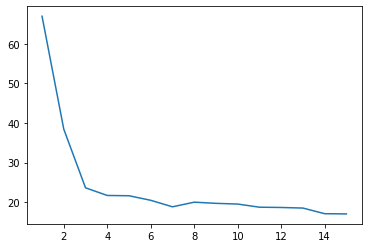

```python
fig=plt.Figure()
ax = plt.axes()
ax.plot(range(1,kmax+1),sse)
```

# Big elbow in K=3

```python
KMEAN=KMeans(n_clusters=3).fit(xtrain)
#use X to predict , so i can get a cluster for each neighborhood
yhat_rosario=KMEAN.predict(X_normalize)
```

### Last lets insert the clustering information into the grupped DF

```python
grupped.insert(3,"Cluster Label",yhat_rosario)
```

```python
data_final_rosario=grupped.copy()
```

```python
map_clusters = folium.Map(location=centro_rosario, zoom_start=11)
kclusters=3
# set color scheme for the clusters
x = np.arange(kclusters)
ys = [i + x + (i*x)**2 for i in range(kclusters)]
colors_array = cm.rainbow(np.linspace(0, 1, len(ys)))
rainbow = [colors.rgb2hex(i) for i in colors_array]

# add markers to the map
markers_colors = []
for lat, lon, poi, cluster in zip(data_final_rosario['Neighborhood Latitude'],
                                  data_final_rosario['Neighborhood Longitude'],
                                  data_final_rosario['Neighborhood'],
                                  data_final_rosario['Cluster Label']):
    label = folium.Popup(str(poi) + ' Cluster ' + str(cluster), parse_html=True)
    folium.CircleMarker(
        [lat, lon],
        radius=8,
        popup=label,
        color=rainbow[cluster-1],
        fill=True,
        fill_color=rainbow[cluster-1],
        fill_opacity=1).add_to(map_clusters)
#for data in ros['GEOJSON']:
#    folium.features.GeoJson(data).add_to(map_clusters)
map_clusters
```

Make this Notebook Trusted to load map: File -> Trust Notebook

[interactive chart not shown]

### Now its turn to get the data of Cordoba

```python
#This is a modified version of the previous function since cordoba data is  presented different that rosario data
def NombreyCoordenadas_CBA(serie,nombres):
   #recibe serie con datos json en string yy serie con nombres de lugarews y devuelva DF y centros
    centro=[]
    barrio=[]
    result={}
    for i,s in enumerate(serie):
        #print(s)
        j=json.loads(s)
        lista=j['geometry']['coordinates'][0] # lista con todos los puntos de los barrios
        #print(lista)
        centro.append(calculateCenter(lista))
        barrio.append(nombres[i])
    result['Barrio']=barrio
    result['Coordenadas']=centro

    return(pd.DataFrame(result),centro)
```

```python
barrios_cba=[]
geojson_cba=[]


for data in cba['features']:
    barrios_cba.append(data['properties']['NOMBRE_BAR'])
    geojson_cba.append(str(data))
```

```python
cba_barrio_json=pd.DataFrame({ 'Barrio':barrios_cba,
                             'GEOJSON':geojson_cba})
```

```python
data_cba,centros_cba=NombreyCoordenadas_CBA(serie=cba_barrio_json['GEOJSON'],nombres=cba_barrio_json['Barrio'])
```

```python
data_cba.reset_index(inplace=True,drop=True)
```

#### Here i Drop some neighborhoods that are only parks

```python
for i,row in enumerate(data_cba['Barrio'].values):
    if bool(search('PARQUE',row)) and not(bool(search('VILLA',row))):
        data_cba.drop(index=i,inplace=True)
```

```python
data_cba.reset_index(inplace=True,drop=True)
```

```python
centro_cba=(-31.416667,-64.183333)
```

```python
aux=distCentro(barrios=data_cba['Barrio'],centro=centro_cba,centro_barrio=data_cba['Coordenadas'])
```

```python
data_cba=data_cba.join(aux.set_index('Barrio'),on='Barrio')
```

```python
data_cba.sort_values(by='Distancia',ascending=True,inplace=True)
data_cba.reset_index(drop=True,inplace=True)
```

```python
data_cba.drop(index=data_cba.index[-173:],inplace=True)
```

```python
venues_found_cba=pd.read_csv('venues_found_cba.csv')
```

```python
venues_found_cba=correctorCategoria(venues_found_cba)
```

[output not shown]

### Once all the venues are collected , i do the same as with rosario getting the dummies

```python
onehot_cba=pd.get_dummies(venues_found_cba,columns=['Venue Category']) # hago onehot
```

```python
data_cba.rename(columns={'Barrio':'Neighborhood'},inplace=True)
data_cba.columns
```

```
Index(['Neighborhood', 'Coordenadas', 'Distancia'], dtype='object')
```

```python
grupped_cba=onehot_cba.groupby('Neighborhood').mean()
grupped_cba.reset_index(inplace=True)
```

```python
grupped_cba.head()
```

|  | Neighborhood | Unnamed: 0 | Neighborhood Latitude | Neighborhood Longitude | Venue Latitude | Venue Longitude | Venue Category_ESCUELA | Venue Category_HOSPITAL | Venue Category_SUPERMERCADO |
| --- | --- | --- | --- | --- | --- | --- | --- | --- | --- |
| 0 | 23 DE ABRIL | 54.0 | -31.457618 | -64.127903 | -31.459500 | -64.126890 | 1.0 | 0.0 | 0.0 |
| 1 | ACHAVAL PENA | 45.0 | -31.436000 | -64.204071 | -31.437338 | -64.202355 | 0.5 | 0.0 | 0.5 |
| 2 | ALBERDI | 32.0 | -31.408745 | -64.201301 | -31.408252 | -64.201567 | 0.5 | 0.5 | 0.0 |
| 3 | ALTA CORDOBA | 7.0 | -31.390438 | -64.184767 | -31.389238 | -64.187126 | 1.0 | 0.0 | 0.0 |
| 4 | ALTO PALERMO | 82.0 | -31.375597 | -64.225362 | -31.376912 | -64.226208 | 0.0 | 0.5 | 0.5 |

```python
#joiin groupped with data_ros to get distance to city center

grupped_cba=grupped_cba.join(data_cba[['Neighborhood','Distancia']].set_index('Neighborhood'),on='Neighborhood')
```

```python
grupped_cba.shape
```

```
(72, 10)
```

```python
grupped_cba.drop(columns='Unnamed: 0',inplace=True)
```

### Using the model already trained with rosario y get the clusters for cordoba

```python
X_cba=grupped_cba.drop(columns=['Neighborhood', 'Neighborhood Latitude', 'Neighborhood Longitude', 'Venue Latitude', 'Venue Longitude'])
X_cba_normalize=StandardScaler().fit_transform(X_cba)

yhat_cordoba=KMEAN.predict(X_cba_normalize)
```

```python
grupped_cba.drop(columns=['Venue Latitude','Venue Longitude'],inplace=True)
grupped_cba.head()
```

|  | Neighborhood | Neighborhood Latitude | Neighborhood Longitude | Venue Category_ESCUELA | Venue Category_HOSPITAL | Venue Category_SUPERMERCADO | Distancia |
| --- | --- | --- | --- | --- | --- | --- | --- |
| 0 | 23 DE ABRIL | -31.457618 | -64.127903 | 1.0 | 0.0 | 0.0 | 0.068916 |
| 1 | ACHAVAL PENA | -31.436000 | -64.204071 | 0.5 | 0.0 | 0.5 | 0.028351 |
| 2 | ALBERDI | -31.408745 | -64.201301 | 0.5 | 0.5 | 0.0 | 0.019637 |
| 3 | ALTA CORDOBA | -31.390438 | -64.184767 | 1.0 | 0.0 | 0.0 | 0.026268 |
| 4 | ALTO PALERMO | -31.375597 | -64.225362 | 0.0 | 0.5 | 0.5 | 0.058764 |

```python
grupped_cba.insert(3,"Cluster Label",yhat_cordoba)
```

```python
grupped_cba.shape
```

```
(72, 8)
```

```python
data_final_cordoba=grupped_cba.copy()
```

```python
map_clusters_cba = folium.Map(location=centro_cba, zoom_start=11)
kclusters=3
# set color scheme for the clusters
x = np.arange(kclusters)
ys = [i + x + (i*x)**2 for i in range(kclusters)]
colors_array = cm.rainbow(np.linspace(0, 1, len(ys)))
rainbow = [colors.rgb2hex(i) for i in colors_array]

# add markers to the map
markers_colors = []
for lat, lon, poi, cluster in zip(data_final_cordoba['Neighborhood Latitude'],
                                  data_final_cordoba['Neighborhood Longitude'],
                                  data_final_cordoba['Neighborhood'],
                                  data_final_cordoba['Cluster Label']):
    label = folium.Popup(str(poi) + ' Cluster ' + str(cluster), parse_html=True)
    folium.CircleMarker(
        [lat, lon],
        radius=8,
        popup=label,
        color=rainbow[cluster-1],
        fill=True,
        fill_color=rainbow[cluster-1],
        fill_opacity=1).add_to(map_clusters_cba)
#for data in ros['GEOJSON']:
#    folium.features.GeoJson(data).add_to(map_clusters)
map_clusters_cba
```

Make this Notebook Trusted to load map: File -> Trust Notebook

[interactive chart not shown]

## Results and Discussion

Considering the final objetive that was to know wich neihborhoods of cordoba will be most suitable to live , based in my personals request , the study gave me a good start point. Since i already live in Rosario , particulary in a Green cluster , i can confirm that the clustering sistem works pretty well . This last thing gave me some real wolrd proof that all this methods can be trusted. Im well aware that using more data as for example mean housing price could help me reduce the amount of options in cordoba city , but the reality is that is not easy to get this infomration for those cities.

## Conclusion

The main challenge of the proyect was to proceess all the data i got from various sources, since they dont follow the same pattern. This proyect gave me a pseudo-"real life" experience when working with data , starting with an idea and morph it into something concrete. Furthermore i learn a lot about Json , in particular GeoJson and all of its uses, and I think this is a really usefull skill for Data Science